# R: Clustering con DBScan y detección de anomalías

Cristian Urbano

# 1 Librerías y Datos

Primero instalamos los paquetes necesarios para hacer el clustering DBScan.

```r
install.packages('fpc') #Recuerde que esto solo se hace una vez
```

```r
library(dplyr)
library(inspectdf)
library(ggpubr)
library(cluster)
library(factoextra)
library(fpc)

options(scipen = 9999) #Para quitar la notación científica

set.seed(1234) #Semilla para generar números aleatorios. Hace reproducibles los resultados.

#Cargamos los datos
datos_original <- read.csv('Mall_Customers.csv')
head(datos_original, 3)
```

```
##   CustomerID Gender Age Annual.Income..k.. Spending.Score..1.100.
## 1          1   Male  19                 15                     39
## 2          2   Male  21                 15                     81
## 3          3 Female  20                 16                      6
```

Esta base de datos contiene 200 clientes de un centro comercial. Note que tenemos 3 variables numéricas y una categórica. Con k-means no podremos usar la categórica. Seleccionamos solo las necesarias e inspeccionamos los datos

```r
datos <- select(datos_original, -CustomerID, -Gender) #el menos antes de la variable significa eliminar

#Inspeccionamos los datos nulos
inspeccion_na <- inspect_na(datos)
inspeccion_na
```

```
## # A tibble: 3 x 3
##   col_name                 cnt  pcnt
##   <chr>                  <int> <dbl>
## 1 Age                        0     0
## 2 Annual.Income..k..         0     0
## 3 Spending.Score..1.100.     0     0
```

Vemos que no tenemos datos faltantes.

# 2 Clustering con DBScan

A diferencia de k-means y otros métodos similares, DBScan no necesita definir el k antes de correrlo. El algoritmo determina el número de grupos automáticamente basado en 2 argumentos:

- Distancia de alcanzabilidad (eps): Es el radio de la vecindad del punto
- Mínimo número de puntos (MinPts): El mínimo número de puntos dentro de la vecindad que hacen al punto un core point (un punto adentro del clúster)

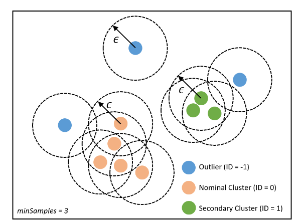

## 2.1 Estandarización y distancias

Estandarizamos las variables numéricas y calculamos las distancias (euclidianas en este caso, pero podría ser otra).

```r
#Estandarizar todas las variables numéricas
datos_estandarizados <- scale(datos)

#Calculamos la amtriz de distancias
matriz_distancias <- dist(datos_estandarizados)^2
```

Este paso es importante, el método DBScan se ve afectado por las diferencias en escalas de las variables.

## 2.2 Correr DBScan

```r
modelo_dbscan <- dbscan(matriz_distancias, eps=0.45, MinPts=5, method='dist')

#Calculamos la silueta
sil_dbscan <- silhouette(modelo_dbscan$cluster, matriz_distancias)

#Graficamos
graf_silueta_dbscan = fviz_silhouette(sil_dbscan)
```

```
##   cluster size ave.sil.width
## 0       0   17         -0.11
## 1       1  183          0.41
```

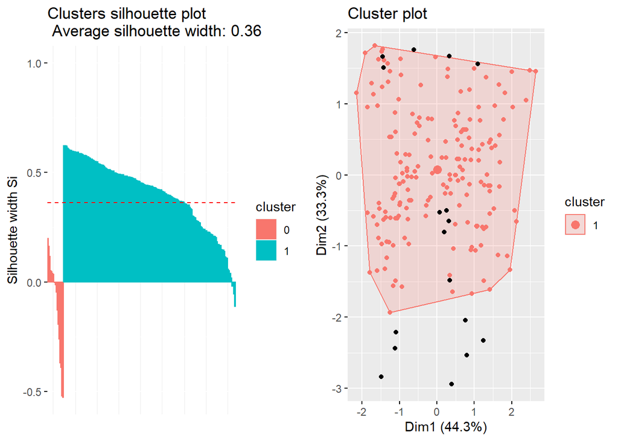

```r
graf_cluster_dbscan = fviz_cluster(modelo_dbscan, data=datos_estandarizados, geom = c('point')) #Si no elijo variables, usa un PCA

#Juntamos los gráficos
ggarrange(graf_silueta_dbscan,graf_cluster_dbscan, nrow=1)
```

Note que el ruido tiene una silueta muy mala, esto es porque no se parecen a ningún grupo. Dejando de lado el ruido, el resto de clusters están bien en términos de la silueta.

Podemos correr otro DBScan con un mayor radio si queremos limitar el ruido.

```r
modelo_dbscan2 <- dbscan(matriz_distancias, eps=0.55, MinPts=5, method='dist')

#Calculamos la silueta
sil_dbscan2 <- silhouette(modelo_dbscan2$cluster, matriz_distancias)

#Graficamos
graf_silueta_dbscan2 = fviz_silhouette(sil_dbscan2)
```

```
##   cluster size ave.sil.width
## 0       0   10         -0.33
## 1       1  190          0.45
```

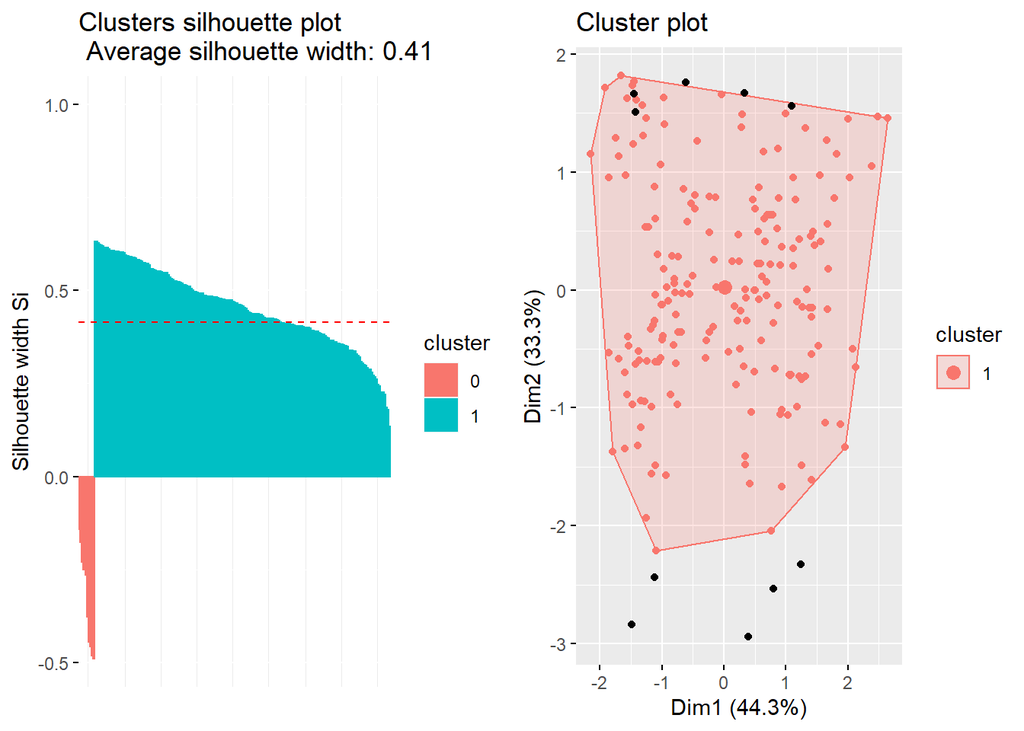

```r
graf_cluster_dbscan2 = fviz_cluster(modelo_dbscan2, data=datos_estandarizados, geom = c('point')) #Si no elijo variables, usa un PCA

#Juntamos los gráficos
ggarrange(graf_silueta_dbscan2,graf_cluster_dbscan2, nrow=1)
```

Note que acá las anomalía son mucho más claras. Es importante jugar con los parámetros dependiendo del resultado que busquemos.

Para el ejercicio seguiremos con este último.

## 2.3 Anomalías

Las anomalías quedan con el cluster 0. Podemos filtrar solo esos datos para investigar su origen.

Primero traemos los clusters asignados por el DBScan a la base original.

```r
datos_original$cluster <- as.character(modelo_dbscan2$cluster)
```

Y procedemos a dejar en la base de datos solo los del cluster 0.

```r
anomalias <- datos_original %>% filter(cluster=='0')
anomalias
```

```
##    CustomerID Gender Age Annual.Income..k.. Spending.Score..1.100. cluster
## 1           1   Male  19                 15                     39       0
## 2           3 Female  20                 16                      6       0
## 3           7 Female  35                 18                      6       0
## 4          12 Female  35                 19                     99       0
## 5          20 Female  35                 23                     98       0
## 6         195 Female  47                120                     16       0
## 7         197 Female  45                126                     28       0
## 8         198   Male  32                126                     74       0
## 9         199   Male  32                137                     18       0
## 10        200   Male  30                137                     83       0
```

Ya con esta base de datos, será tarea de un analista revisar manualmente cada observación para determinar su verdadera naturaleza (si son correctos o son observaciones fraudulentas, por ejemplo).